# Mining the Brundy and Thornton (2021) dataset

# Introduction

[Thornton and Brundy (2021)](https://doi.org/10.7710/2162-3309.2410) studied the journal prices charged by Elsevier to five different academic institutions in the USA. These prices were negotiated and differed from the [list prices](https://www.elsevier.com/books-and-journals/journal-pricing/print-price-list) available on Elsevier’s web site. I think this is a valuable study as it shows the variance paid for titles by different institutions for individual titles (as opposed to a “big deal” bundle for all of ScienceDirect content).

The data underlying their paper are available via [figshare](https://figshare.com/articles/dataset/2020_Elsevier_Journal_Title_Level_Pricing_for_Five_U_S_Research_Universities/13557536). I have downloaded these files, fixing what I think are a few [minor issues](https://github.com/sje30/thornton21/blob/master/data/sjenotes.org) when working with these data in R. The data were provided separately for each institution, so here I reassemble them so that they are arranged into a table, one row per journal, and columns for each institution.

The key variable is termed *ALP: Adjustment from List Price*. This is the percentage difference from list price (negative values meaning a reduction paid compared to list price).

This interactive document allows you to search by journal, or sort the data by various columns in the combined dataset.

This interactive document is generated by Rmarkdown, and all source data are available at https://github.com/sje30/thornton21.

## Read in the data files

These were cleaned up (notes elsewhere) so that they could be read into R. One column seems to be incorrect, which needs fixing.

```r
f <- read_check_data("data/FS_2020_Pricelist2.csv", "FS")
i <- read_check_data("data/ISU_2020_Pricelist2.csv", "ISU")
i$ALP <- i$ALP * -1 #bug -- see below
c <- read_check_data("data/UNC_2020_Pricelist2.csv", "UNC")
a <- read_check_data("data/IA_2020_Pricelist2.csv", "IA")
v <- read_check_data("data/WVU_2020_Pricelist2.csv", "WVU")
dat <- rbind(f, i, c, a, v)
```

Note - bug in the data: ALPs for ISU (Iowa) are the wrong sign.

[output not shown]

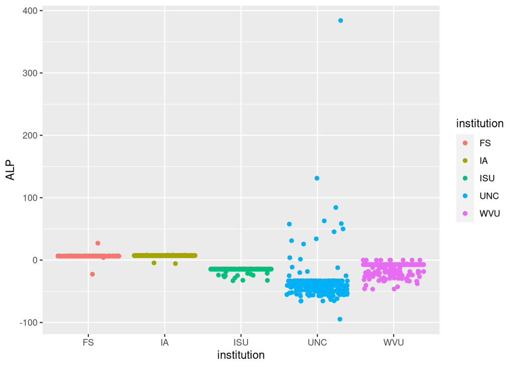

## Journals with high ALP

e.g. find those greater than 30% than list price. No surprises that the outlier (384% ALP) is the journal *Cell*.

```r
DT::datatable(filter(dat, ALP>=30))
```

|  | ISSN | Title | published | final | Difference | ALP | institution |
| --- | --- | --- | --- | --- | --- | --- | --- |
| 1 | 0006-3495 | Biophysical Journal | 2332 | 3681.03 | 1349.03 | 57.8 | UNC |
| 2 | 0092-8674 | Cell | 2713 | 13133.75 | 10420.75 | 384.1 | UNC |
| 3 | 1074-7613 | Immunity | 2038 | 2963.73 | 925.73 | 45.4 | UNC |
| 4 | 1525-0016 | Molecular Therapy | 2801 | 3671.41 | 870.41 | 31.1 | UNC |
| 5 | 0002-9297 | The American Journal of Human Genetics | 1948 | 2611.65 | 663.65 | 34.1 | UNC |
| 6 | 0002-8177 | The Journal of the American Dental Association | 358 | 828 | 470 | 131.3 | UNC |
| 7 | 2213-8587 | The Lancet Diabetes &amp; Endocrinology | 2189 | 3565.33 | 1376.33 | 62.9 | UNC |
| 8 | 2468-1253 | The Lancet Gastroenterology &amp; Hepatology | 1946 | 2919.03 | 973.03 | 50 | UNC |
| 9 | 2215-0366 | The Lancet Psychiatry | 2169 | 3438 | 1269 | 58.5 | UNC |
| 10 | 2213-2600 | The Lancet Respiratory Medicine | 2127 | 3919.33 | 1792.33 | 84.3 | UNC |

## Journals with low ALP

e.g. find those with at least 30% saving on list price.

```r
DT::datatable(filter(dat, ALP<=-30))
```

|  | ISSN | Title | published | final | Difference | ALP | institution |
| --- | --- | --- | --- | --- | --- | --- | --- |
| 1 | 0016-5085 | Gastroenterology | 2239 | 1516.77 | -722.23 | -32.3 | ISU |
| 2 | 0737-0806 | Journal of Equine Veterinary Science | 1165 | 779.76 | -385.24 | -33.1 | ISU |
| 3 | 1557-5063 | Journal of Exotic Pet Medicine | 893 | 602.78 | -290.23 | -32.5 | ISU |
| 4 | 1876-2859 | Academic Pediatrics | 582 | 273.99 | -308.01 | -52.9 | UNC |
| 5 | 0001-4575 | Accident Analysis &amp; Prevention | 4246 | 2523.57 | -1722.43 | -40.6 | UNC |
| 6 | 1742-7061 | Acta Biomaterialia | 2109 | 1406 | -703 | -33.3 | UNC |
| 7 | 2173-5735 | Acta Otorrinolaringol�gica -English Edition | 1105 | 736.67 | -368.33 | -33.3 | UNC |
| 8 | 0169-409X | Advanced Drug Delivery Reviews | 11283 | 6705.93 | -4577.07 | -40.6 | UNC |
| 9 | 1548-5595 | Advances in Chronic Kidney Disease | 704 | 423.33 | -280.67 | -39.9 | UNC |
| 10 | 0741-8329 | Alcohol | 3865 | 2020.16 | -1844.84 | -47.7 | UNC |

[output cut: 376 more lines]

## Raw database of files.

here you can search for individual journals, or sort them by ranking the different columns.

e.g. by searching for “Trends in Genetics” you can see the variance in price paid by 3 institutions.

```r
DT::datatable(dat)
```

|  | ISSN | Title | published | final | Difference | ALP | institution |
| --- | --- | --- | --- | --- | --- | --- | --- |
| 1 | 0001-4575 | Accident Analysis &amp; Prevention | 4246 | 4520.33 | 274.33 | 6.46 | FS |
| 2 | 1359-6454 | Acta Materialia | 6247 | 6650.62 | 403.62 | 6.46 | FS |
| 3 | 0003-2670 | Analytica Chimica Acta | 16105 | 17145.52 | 1040.52 | 6.46 | FS |
| 4 | 0003-3472 | Animal Behaviour | 1995 | 2123.89 | 128.89 | 6.46 | FS |
| 5 | 0195-6663 | Appetite | 2766 | 2944.7 | 178.7 | 6.46 | FS |
| 6 | 0306-2619 | Applied Energy | 7304 | 7775.9 | 471.9 | 6.46 | FS |
| 7 | 0143-6228 | Applied Geography | 1758 | 1871.58 | 113.58 | 6.46 | FS |
| 8 | 0005-7967 | Behaviour Research and Therapy | 3916 | 4169.01 | 253.01 | 6.46 | FS |
| 9 | 0166-4328 | Behavioural Brain Research | 12665 | 13483.25 | 818.25 | 6.46 | FS |
| 10 | 0006-291X | Biochemical and Biophysical Research Communications | 14921 | 15885.02 | 964.02 | 6.46 | FS |

[output cut: 1532 more lines]

## Variance of prices

```r
f1 = f %>% select(Title, published,  FS=ALP)
i1 = i %>% select(Title, published, ISU=ALP)
c1 = c %>% select(Title, published, UNC=ALP)
a1 = a %>% select(Title, published,  IA=ALP)
v1 = v %>% select(Title, published, WVU=ALP)
dat1 <- full_join(f1, i1) %>% full_join(c1) %>% full_join(a1) %>% full_join(v1)
dat2 <- dat1 %>% select(FS, ISU, UNC, IA, WVU) %>% mutate(count=rowSums(!is.na(.)))
dat1$count <- dat2$count
```

Most journals are subscribed to by only one journal:

```r
table(dat1$count)
```

```
##
##   1   2   3   4   5
## 469 237  93  40  32
```

This table shows for each journal in the database the price paid by each institution. The column ‘count’ indicates the number of institutions that subscribed to that journal, and varies between 1 and 5.

```r
DT::datatable(dat1)
```

|  | Title | published | FS | ISU | UNC | IA | WVU | count |
| --- | --- | --- | --- | --- | --- | --- | --- | --- |
| 1 | Accident Analysis &amp; Prevention | 4246 | 6.46 | -14.5 | -40.6 | 7.3 | -7.2 | 5 |
| 2 | Acta Materialia | 6247 | 6.46 | -14.5 |  |  |  | 2 |
| 3 | Analytica Chimica Acta | 16105 | 6.46 | -14.5 | -33.3 |  |  | 3 |
| 4 | Animal Behaviour | 1995 | 6.46 | -14.5 | -40.6 | 7.3 | -7.2 | 5 |
| 5 | Appetite | 2766 | 6.46 | -14.5 | -40.6 |  |  | 3 |
| 6 | Applied Energy | 7304 | 6.46 | -14.5 |  | 7.3 | 0 | 4 |
| 7 | Applied Geography | 1758 | 6.46 | -14.5 |  | 7.3 | -7.2 | 4 |
| 8 | Behaviour Research and Therapy | 3916 | 6.46 |  | -40.6 | 7.3 | -7.2 | 4 |
| 9 | Behavioural Brain Research | 12665 | 6.46 | -14.5 | -40.6 |  | -7.2 | 4 |
| 10 | Biochemical and Biophysical Research Communications | 14921 | 6.46 | -14.5 | -40.6 | 7.3 | -7.2 | 5 |

[output cut: 861 more lines]

## Things to do

1. Use plotly.R to make figure interactive.
2. Cite reference to the paper.
3. Recompute Table 4 using summary().